# SO Anwers

2024-09-30

SO Question: https://stackoverflow.com/questions/58508859/r-officer-package-how-to-specify-a-certain-placeholder-when-there-are-multiple

As of yesterday, `{officer}` version `0.6.7` is available on CRAN. We introduced several new features that also help handling placeholders (phs) with duplicate labels.

1. Dedupe ph labels using `layout_dedupe_ph_labels()`
2. Rename ph labels using `layout_rename_ph_labels()`
3. Reference a ph by `id` using `ph_location_id()`
4. Reference a ph by `type` + `type_idx` using `ph_location_type()`

The first two options work by renaming ph labels and then referencing them by their label. The latter two reference a ph directly despite duplicate labels. The package also contains the sample file `ph_dupes.pptx` with duplicate placeholder labels. The label `Content 7` exists twice.

```r
library(officer)
file <- system.file("doc_examples", "ph_dupes.pptx", package = "officer")
x <- read_pptx(file)
```

All ph information you need for options 2-4 (`type`, `type_idx`, `id`, `ph_label`) is given by `layout_properties()` or `plot_layout_properties()`. Option 1 does not require additional information.

```r
layout_properties(x, "2-dupes")[, 3:6] # relevant columns only
```

```
##     type type_idx id               ph_label
## 1  title        1  2                Title 1
## 2   body        1  8              Content 7
## 3   body        2 10              Content 7
## 4     dt        1  3     Date Placeholder 2
## 5    ftr        1  4               Footer 3
## 6 sldNum        1  5 Slide No Placeholder 4
```

The following plot also contains the `type [type_idx]` (blue), the `ph_label` (red), and the `id` (green).

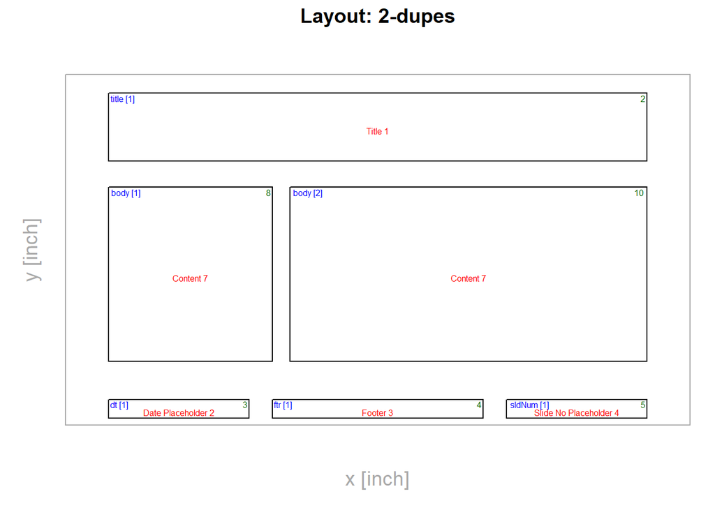

```r
plot_layout_properties(x, "2-dupes")
```

### 1. Dedupe phs using `layout_dedupe_ph_labels()`

After running `layout_dedupe_ph_labels()`, the ph labels are unique and can be referenced using `ph_location_label()`.

```r
layout_dedupe_ph_labels(x, action = "rename")
layout_properties(x, "2-dupes")[, 3:6]
```

```
##     type type_idx id               ph_label
## 1  title        1  2                Title 1
## 2   body        1  8            Content 7.1
## 3   body        2 10            Content 7.2
## 4     dt        1  3     Date Placeholder 2
## 5    ftr        1  4               Footer 3
## 6 sldNum        1  5 Slide No Placeholder 4
```

### 2. Rename duplicated label using `layout_rename_ph_labels()`

`layout_rename_ph_labels()` allows custom renaming of labels. For example, we could rename the two labels from before as follows. Both options generate the same result.

```r
layout_rename_ph_labels(x, "2-dupes", "8" = "New 1", "10" = "New 2") # using id = value pairs
layout_rename_ph_labels(x, "2-dupes", id = c(8, 10)) <- c("New 1", "New 2") # ids + rhs assignment
layout_properties(x, "2-dupes")[, 3:6]
```

```
##     type type_idx id               ph_label
## 1  title        1  2                Title 1
## 2   body        1  8                  New 1
## 3   body        2 10                  New 2
## 4     dt        1  3     Date Placeholder 2
## 5    ftr        1  4               Footer 3
## 6 sldNum        1  5 Slide No Placeholder 4
```

### 3. Reference phs via their unique id using `ph_location_id()`

Alternatively, you may leave the duplicate labels unchanged and instead reference a ph directly by its `id` (column `id` in output above).

```r
x <- x |>
  add_slide("2-dupes", "Master1") |>
  ph_with("Text 1", ph_location_id(id = 8)) |>
  ph_with("Text 2", ph_location_id(id = 10))
```

### 4. Reference a ph by `type` + `type_idx` using `ph_location_type()`

For each ph `type` (e.g., *body*), there is a running index (`type_idx`) ordered by position (*top -> bottom*, *left-> right*). Combine `type` and `type_idx` uniquely reference a ph in `ph_location_type()`.

```r
x <- x |>
  add_slide("2-dupes", "Master1") |>
  ph_with("Text New 1", ph_location_type(type = "body", type_idx = 1)) |>
  ph_with("Text New 1", ph_location_type(type = "body", type_idx = 2))
```